# Neural Network vs Multiple Linear Regression

Kyriakos Theodorides

26/04/2020

```r
knitr::opts_chunk$set(error = TRUE)
```

```r
library(bannerCommenter)
       banner("Marketing Analytics","Individual Research:","Kyriakos Theodorides","Imperial College London", emph = TRUE)
```

```
##
## ###########################################################################
## ###########################################################################
## ###                                                                     ###
## ###                         MARKETING ANALYTICS                         ###
## ###                        INDIVIDUAL RESEARCH:                         ###
## ###                        KYRIAKOS THEODORIDES                         ###
## ###                       IMPERIAL COLLEGE LONDON                       ###
## ###                                                                     ###
## ###########################################################################
## ###########################################################################
```

```r
library(neuralnet)  # regression
library(tidyverse)
library(caret)
library(nnet) # classification
library(NeuralNetTools)
library(plyr)
library(h2o)
```

```r
library(ggplot2)
library(dplyr)
library(keras)
library(dplyr)
library(cloudml)
```

# NEURAL NETWORK

```r
# Data Loading
startups <- read.csv("50_startups.csv")
class(startups)
```

```
## [1] "data.frame"
```

```r
head(startups)
```

```
##   R.D.Spend Administration Marketing.Spend      State   Profit
## 1  165349.2      136897.80        471784.1   New York 192261.8
## 2  162597.7      151377.59        443898.5 California 191792.1
## 3  153441.5      101145.55        407934.5    Florida 191050.4
## 4  144372.4      118671.85        383199.6   New York 182902.0
## 5  142107.3       91391.77        366168.4    Florida 166187.9
## 6  131876.9       99814.71        362861.4   New York 156991.1
```

```r
#make State variable numeric in order to eliminate any errors while modelling
startups$State <- as.numeric(revalue(startups$State,
                          c("New York"="0", "California"="1",
                            "Florida"="2")))
#str(startups)
```

```r
#compute the correlations
cor(startups)
```

```
##                 R.D.Spend Administration Marketing.Spend      State    Profit
## R.D.Spend       1.0000000     0.24195525      0.72424813 0.10468511 0.9729005
## Administration  0.2419552     1.00000000     -0.03215388 0.01184720 0.2007166
## Marketing.Spend 0.7242481    -0.03215388      1.00000000 0.07766961 0.7477657
## State           0.1046851     0.01184720      0.07766961 1.00000000 0.1017963
## Profit          0.9729005     0.20071657      0.74776572 0.10179631 1.0000000
```

Normalize the dataset

```r
#normalise data
maxs <- apply(startups, 2, max)
mins <- apply(startups, 2, min)
scaled <- as.data.frame(scale(startups, center = mins, scale = maxs - mins))
```

Split the data into train and test set

```r
## set the seed to make your partition reproducible
#set.seed(123)

train_ind <- sample(seq_len(nrow(startups)), size = floor(nrow(startups) * 0.7))

train <- scaled[train_ind,]
test <- scaled[-train_ind,]
```

Model a neural network model with training data

```r
nn_model <- neuralnet(Profit~ R.D.Spend + Administration
                            + Marketing.Spend + State,
                      data = train,
                      linear.output = TRUE,
                      err.fct = 'sse'
                      )
str(nn_model)
```

```
## List of 14
##  $ call               : language neuralnet(formula = Profit ~ R.D.Spend + Administration + Marketing.Spend +      State, data = train, err.fct = "| __truncated__
##  $ response           : num [1:35, 1] 0.373 0.997 0.466 0.794 0.715 ...
##   ..- attr(*, "dimnames")=List of 2
##   .. ..$ : chr [1:35] "40" "2" "33" "8" ...
##   .. ..$ : chr "Profit"
##  $ covariate          : num [1:35, 1:4] 0.233 0.983 0.383 0.788 0.568 ...
##   ..- attr(*, "dimnames")=List of 2
##   .. ..$ : chr [1:35] "40" "2" "33" "8" ...
##   .. ..$ : chr [1:4] "R.D.Spend" "Administration" "Marketing.Spend" "State"
##  $ model.list         :List of 2
##   ..$ response : chr "Profit"
##   ..$ variables: chr [1:4] "R.D.Spend" "Administration" "Marketing.Spend" "State"
##  $ err.fct            :function (x, y)
##   ..- attr(*, "type")= chr "sse"
##  $ act.fct            :function (x)
##   ..- attr(*, "type")= chr "logistic"
##  $ linear.output      : logi TRUE
##  $ data               :'data.frame': 35 obs. of  5 variables:
##   ..$ R.D.Spend      : num [1:35] 0.233 0.983 0.383 0.788 0.568 ...
##   ..$ Administration : num [1:35] 0.241 0.762 0.593 0.717 0.579 ...
##   ..$ Marketing.Spend: num [1:35] 0.3709 0.9409 0.0977 0.6865 0.5296 ...
##   ..$ State          : num [1:35] 0 0 0 0.5 0.5 0.5 1 1 1 1 ...
##   ..$ Profit         : num [1:35] 0.373 0.997 0.466 0.794 0.715 ...
##  $ exclude            : NULL
##  $ net.result         :List of 1
##   ..$ : num [1:35, 1] 0.408 0.95 0.479 0.823 0.663 ...
##   .. ..- attr(*, "dimnames")=List of 2
##   .. .. ..$ : chr [1:35] "40" "2" "33" "8" ...
##   .. .. ..$ : NULL
##  $ weights            :List of 1
##   ..$ :List of 2
##   .. ..$ : num [1:5, 1] -0.95295 2.18583 0.00837 0.4357 -0.06358
##   .. ..$ : num [1:2, 1] -0.171 1.344
##  $ generalized.weights:List of 1
##   ..$ : num [1:35, 1:4] 2.98 8.55 2.94 3.89 3.1 ...
##   .. ..- attr(*, "dimnames")=List of 2
##   .. .. ..$ : chr [1:35] "40" "2" "33" "8" ...
##   .. .. ..$ : NULL
##  $ startweights       :List of 1
##   ..$ :List of 2
##   .. ..$ : num [1:5, 1] -0.708 -1.181 0.774 0.502 0.152
##   .. ..$ : num [1:2, 1] -0.804 0.425
##  $ result.matrix      : num [1:10, 1] 0.03752 0.00984 152 -0.95295 2.18583 ...
##   ..- attr(*, "dimnames")=List of 2
##   .. ..$ : chr [1:10] "error" "reached.threshold" "steps" "Intercept.to.1layhid1" ...
##   .. ..$ : NULL
##  - attr(*, "class")= chr "nn"
```

```r
summary(nn_model)
```

```
##                     Length Class      Mode
## call                  5    -none-     call
## response             35    -none-     numeric
## covariate           140    -none-     numeric
## model.list            2    -none-     list
## err.fct               1    -none-     function
## act.fct               1    -none-     function
## linear.output         1    -none-     logical
## data                  5    data.frame list
## exclude               0    -none-     NULL
## net.result            1    -none-     list
## weights               1    -none-     list
## generalized.weights   1    -none-     list
## startweights          1    -none-     list
## result.matrix        10    -none-     numeric
```

Plot nn

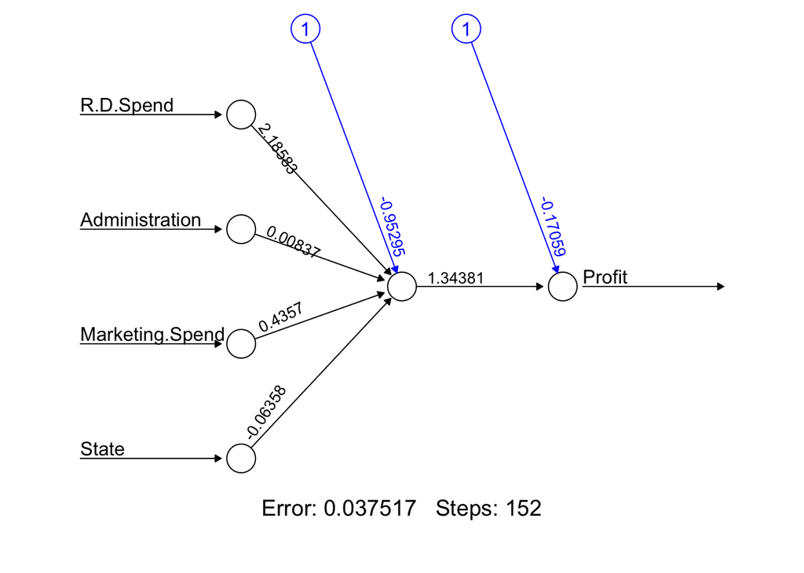

```r
#rep='best' means it plots the repetition with the smallest error
plot(nn_model, rep = "best")
```

Compute Error and Compare Performance

```r
nn_model$result.matrix['error',]
```

```
##      error
## 0.03751685
```

```r
# Evaluating model performance

set.seed(12323)
nn_performance <- neuralnet::compute(nn_model, test[1:4])
predicted_profit <- nn_performance$net.result

# Predicted profit Vs Actual profit of test data.
cor(predicted_profit,test$Profit)
```

```
##           [,1]
## [1,] 0.9591552
```

De-normalise the data and get RMSE

```r
#revert the fitted value back to original scale
fitted.train <- nn_model$net.result[[1]] * (max(startups$Profit)-min(startups$Profit))+min(startups$Profit)

#use the index to get the original value of profit in train dataset.
train.r <- startups$Profit[train_ind]

#calculate the Root Mean Squared Error of train dataset
rmse.train <- (sum((train.r - fitted.train )^2)/nrow(fitted.train))^0.5

rmse.train
```

```
## [1] 8222.223
```

Improve the model performance by increasing hidden neurons

```r
# Improve the model performance :
set.seed(12345)
nn2 <- neuralnet(Profit~R.D.Spend+Administration
        +Marketing.Spend+State,
        data = train,
        linear.output=TRUE,
        err.fct = 'sse',
        hidden = 2)
```

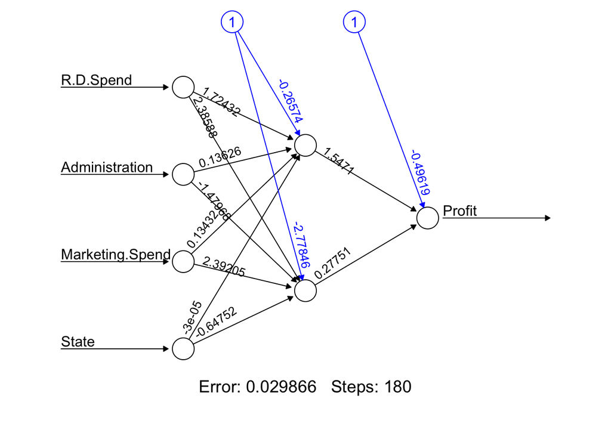

```r
#rep='best' means it plots the repetition with the smallest error
plot(nn2 ,rep = "best")
```

```r
summary(nn2)
```

```
##                     Length Class      Mode
## call                  6    -none-     call
## response             35    -none-     numeric
## covariate           140    -none-     numeric
## model.list            2    -none-     list
## err.fct               1    -none-     function
## act.fct               1    -none-     function
## linear.output         1    -none-     logical
## data                  5    data.frame list
## exclude               0    -none-     NULL
## net.result            1    -none-     list
## weights               1    -none-     list
## generalized.weights   1    -none-     list
## startweights          1    -none-     list
## result.matrix        16    -none-     numeric
```

Compute Error and Compare Performance

```r
nn2$result.matrix['error',]
```

```
##      error
## 0.02986647
```

```r
# Evaluating 2nd model performance
nn_performance2 <- neuralnet::compute(nn2,test[1:4])
predicted_profit2 <- nn_performance2$net.result

# Predicted profit Vs Actual profit of test data.
cor(predicted_profit2,test$Profit)
```

```
##           [,1]
## [1,] 0.9645993
```

De-normalise the data and get RMSE

```r
#revert the fitted value back to original scale
fitted.train2 <- nn2$net.result[[1]] * (max(startups$Profit)-min(startups$Profit))+min(startups$Profit)

#use the index to get the original value of profit in train dataset.
train.r2 <- startups$Profit[train_ind]

#calculate the Root Mean Squared Error of train dataset
rmse.train2 <- (sum((train.r2 - fitted.train2 )^2)/nrow(fitted.train2))^0.5

rmse.train2
```

```
## [1] 7336.147
```

De-normalise the data and get the Actual Profits Predictions

```r
# since the prediction is in Normalized form, we need to de-normalize it
# to get the actual prediction on profit
str_max <- max(startups$Profit)
str_min <- min(startups$Profit)

unnormalize <- function(x, min, max) {
  return( (max - min)*x + min )
}
```

```r
ActualProfit_pred2 <- unnormalize(predicted_profit2, str_min, str_max)
head(ActualProfit_pred2)
```

```
##        [,1]
## 1  187560.6
## 19 131811.4
## 21 123446.6
## 23 118622.7
## 24 114245.3
## 25 110850.7
```

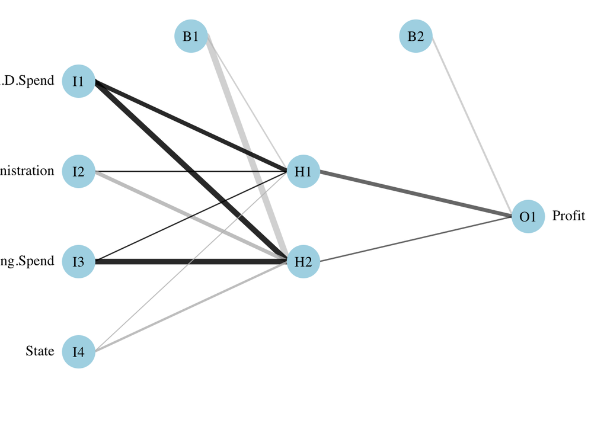

```r
par(mar = numeric(4), family = 'serif')
plotnet(nn2, alpha = 0.6)
```

SSE(Error) has been reduced and training steps had been increased as the number of neurons under hidden layer are increased from 1 to 2

# MULTIPLE LINEAR REGRESSION

Load data

```r
df <- read.csv("50_startups.csv")
```

```r
df$State <- as.numeric(revalue(df$State,
                          c("New York"="0", "California"="1",
                            "Florida"="2")))
```

Creating Dependent and Independent Variable

```r
dependent_variable = c("Profit")
independent_variable<-  names(df)[(!(names(df) %in% c('Profit')))]
```

Assumptions of Linear Regression: 1) Multivariate normality 2) Linear Relationship 3) No Multicollinearity 4) Heteroscedasticity

Distribution of variables for normality checks

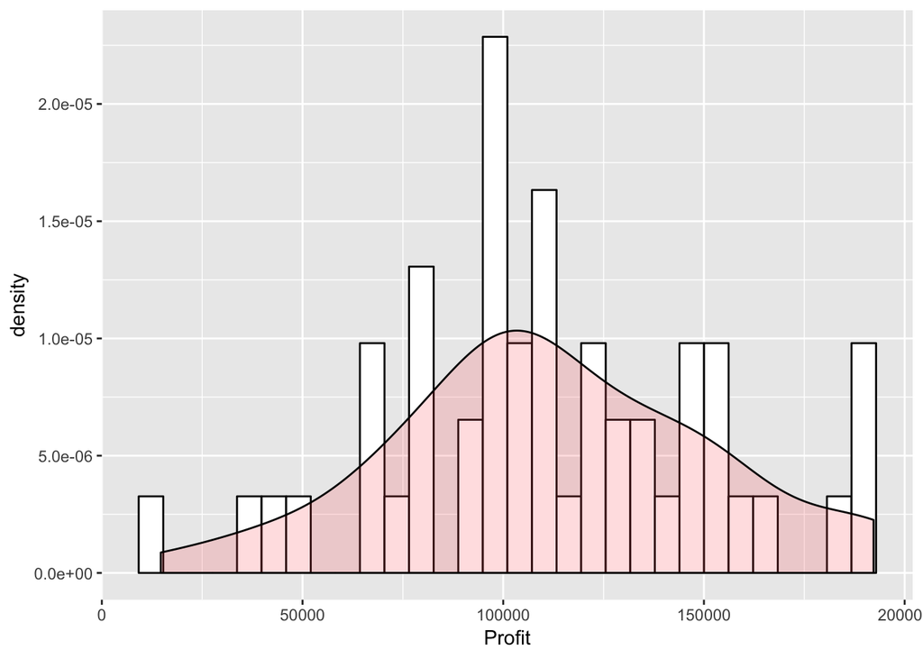

```r
ggplot(df, aes(x=Profit)) + geom_histogram(aes(y=..density..),colour="black", fill="white") +
  geom_density(alpha=.2, fill="#FF6666")
```

Correlation Check to establish Linear Relationship

```r
cor(df$Profit , df[independent_variable])
```

```
##      R.D.Spend Administration Marketing.Spend     State
## [1,] 0.9729005      0.2007166       0.7477657 0.1017963
```

Correlation between Independent Variables

```r
cor(df[independent_variable] , df[independent_variable])
```

```
##                 R.D.Spend Administration Marketing.Spend      State
## R.D.Spend       1.0000000     0.24195525      0.72424813 0.10468511
## Administration  0.2419552     1.00000000     -0.03215388 0.01184720
## Marketing.Spend 0.7242481    -0.03215388      1.00000000 0.07766961
## State           0.1046851     0.01184720      0.07766961 1.00000000
```

```r
set.seed(40)
#Random numbers
randomobs <- sample(seq_len(nrow(df)), size = floor(0.7 * nrow(df)))

# Train dataset
train.df <- df[randomobs,]

#Test dataset
test.df <- df[-randomobs,]
```

Fittina Multiple Linear Regression

```r
mlr_model <- lm( Profit ~ . ,train.df)
summary(mlr_model)
```

```
##
## Call:
## lm(formula = Profit ~ ., data = train.df)
##
## Residuals:
##    Min     1Q Median     3Q    Max
## -33996  -4890    215   8293  15844
##
## Coefficients:
##                   Estimate Std. Error t value Pr(>|t|)
## (Intercept)      5.187e+04  1.278e+04   4.059 0.000324 ***
## R.D.Spend        7.924e-01  6.720e-02  11.792 8.64e-13 ***
## Administration  -4.347e-02  8.576e-02  -0.507 0.615912
## Marketing.Spend  2.886e-02  2.618e-02   1.102 0.279019
## State            5.865e+02  2.326e+03   0.252 0.802635
## ---
## Signif. codes:  0 '***' 0.001 '**' 0.01 '*' 0.05 '.' 0.1 ' ' 1
##
## Residual standard error: 10690 on 30 degrees of freedom
## Multiple R-squared:  0.9384, Adjusted R-squared:  0.9302
## F-statistic: 114.3 on 4 and 30 DF,  p-value: < 2.2e-16
```

The above representation shows the summary of a multiple linear regression model. The first table shows the distribution of the residuals or the error terms. The second table gives us the statistics about the co-efficients of the variables 1) Estimate - This is the co-efficent of the variables in the equation 2) Std. Error - This represents the deviation in the co-efficient if different samples with the same distribution are used for modelling 3) t value - Test statistic derived from the estimate and standard error computed as the ratio of the two variables (Estimate / Standard Error) 4) Pr(>|t|) - This is the p-value derived from the test statistic used for determinimg the importance of the variable.

Compute RMSE

```r
pred_regression <- predict(mlr_model, test.df %>% select(-Profit),type='response')

print(sqrt(mean((test.df$Profit - pred_regression)^2)))
```

```
## [1] 5964.449
```

```r
#compute R-square
R2(pred_regression, test$Profit)
```

```
## [1] 0.9180237
```

Compare predictions

```r
final <- head(data.frame(preds_nn = ActualProfit_pred2 , preds_lr = pred_regression, actual=test.df$Profit))
knitr::kable((final))
```

[output not shown]

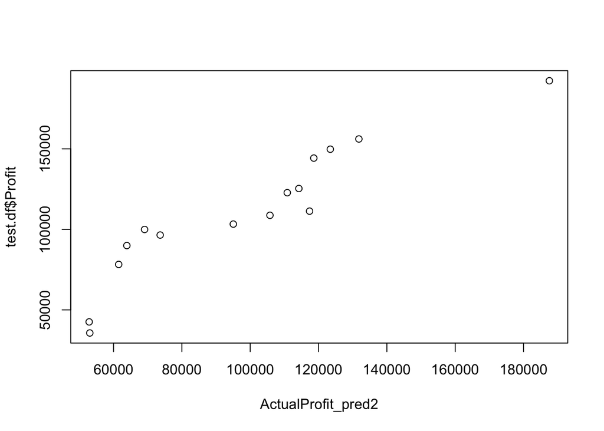

```r
#test.df has the de-normalised ovserved values
plot(ActualProfit_pred2,test.df$Profit)
```

References:  
https://rpubs.com/thirus83/453911  
https://rpubs.com/shyambv/linear_neural_network  
Dr. Gokhan Yildirim Lectures